# TestAssignment

Nancy

8/14/2020

### TestAssignment Package - Overview

This is an R package which created as part of the last assignment for the coursera lesson “Building an R Package” which is a part of the “Mastering Software Development in R Specialization”.

This package includes the following functions:

- fars_read
- make_filename
- fars_read_years
- fars_summarize_years
- fars_map_state

##### **Input Files**:

As input for this assignment we are using data from the US National Highway Traffic Safety Administration’s Fatality Analysis Reporting System, which is a nationwide census providing the American public yearly data regarding fatal injuries suffered in motor vehicle traffic crashes.

A sample of the data are:

```
## # A tibble: 6 x 50
##   STATE ST_CASE VE_TOTAL VE_FORMS PVH_INVL  PEDS PERNOTMVIT PERMVIT PERSONS
##   <dbl>   <dbl>    <dbl>    <dbl>    <dbl> <dbl>      <dbl>   <dbl>   <dbl>
## 1     1   10001        1        1        0     0          0       8       8
## 2     1   10002        2        2        0     0          0       2       2
## 3     1   10003        1        1        0     0          0       1       1
## 4     1   10004        1        1        0     0          0       3       3
## 5     1   10005        2        2        0     0          0       3       3
## 6     1   10006        2        2        0     0          0       3       3
## # ... with 41 more variables: COUNTY <dbl>, CITY <dbl>, DAY <dbl>, MONTH <dbl>,
## #   YEAR <dbl>, DAY_WEEK <dbl>, HOUR <dbl>, MINUTE <dbl>, NHS <dbl>,
## #   ROAD_FNC <dbl>, ROUTE <dbl>, TWAY_ID <chr>, TWAY_ID2 <chr>, MILEPT <dbl>,
## #   LATITUDE <dbl>, LONGITUD <dbl>, SP_JUR <dbl>, HARM_EV <dbl>,
## #   MAN_COLL <dbl>, RELJCT1 <dbl>, RELJCT2 <dbl>, TYP_INT <dbl>,
## #   WRK_ZONE <dbl>, REL_ROAD <dbl>, LGT_COND <dbl>, WEATHER1 <dbl>,
## #   WEATHER2 <dbl>, WEATHER <dbl>, SCH_BUS <dbl>, RAIL <chr>, NOT_HOUR <dbl>,
## #   NOT_MIN <dbl>, ARR_HOUR <dbl>, ARR_MIN <dbl>, HOSP_HR <dbl>, HOSP_MN <dbl>,
## #   CF1 <dbl>, CF2 <dbl>, CF3 <dbl>, FATALS <dbl>, DRUNK_DR <dbl>
```

##### **Final Output**:

The final output is given through the execution of the “fars_map_state”. This function returns a plot of the incidences for the specified year and state. Specifically, it will return a map of the state specified including the incidences as dots.

Below you can find an example of the incidences for state **45** and year **2013**:

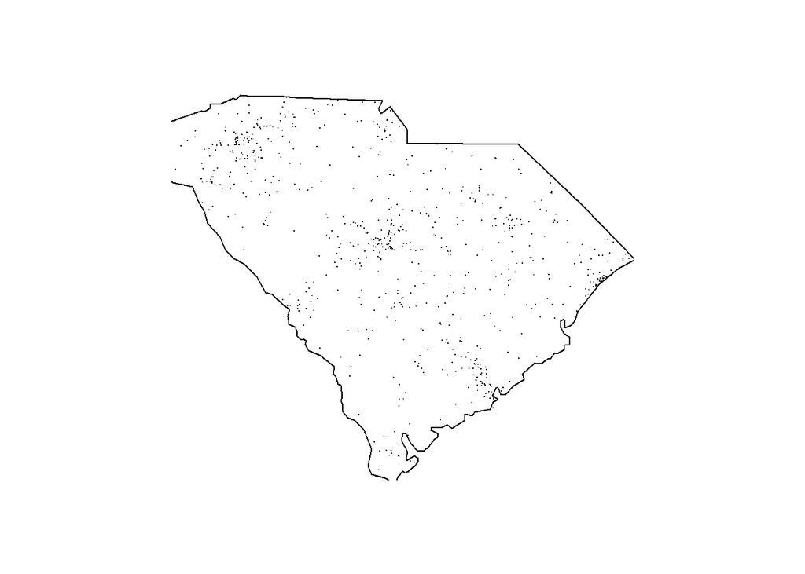

## Testing

I am working in Windows environment so Travis could not proceed with the testing, this is why I tested it also with appveyor which is the most suitable option for this operating system.

##### Travis Badge

[figure not shown]

##### appveyor Badge

[figure not shown]